# Project_Full_Code_Notebook_EasyVisa

[figure not shown]

Data Science and Business Analytics

Ensemble Techniques and Model Tuning

[figure not shown]

Visa Approval Facilitation

# **Problem Statement**

## Context

Business communities in the United States are facing high demand for human resources, but one of the constant challenges is identifying and attracting the right talent, which is perhaps the most important element in remaining competitive. Companies in the United States look for hard-working, talented, and qualified individuals both locally as well as abroad.

The Immigration and Nationality Act (INA) of the US permits foreign workers to come to the United States to work on either a temporary or permanent basis. The act also protects US workers against adverse impacts on their wages or working conditions by ensuring US employers' compliance with statutory requirements when they hire foreign workers to fill workforce shortages. The immigration programs are administered by the Office of Foreign Labor Certification (OFLC).

OFLC processes job certification applications for employers seeking to bring foreign workers into the United States and grants certifications in those cases where employers can demonstrate that there are not sufficient US workers available to perform the work at wages that meet or exceed the wage paid for the occupation in the area of intended employment.

## Objective

In FY 2016, the OFLC processed 775,979 employer applications for 1,699,957 positions for temporary and permanent labor certifications. This was a nine percent increase in the overall number of processed applications from the previous year. The process of reviewing every case is becoming a tedious task as the number of applicants is increasing every year.

The increasing number of applicants every year calls for a Machine Learning based solution that can help in shortlisting the candidates having higher chances of VISA approval. OFLC has hired the firm EasyVisa for data-driven solutions. You as a data scientist at EasyVisa have to analyze the data provided and, with the help of a classification model:

- Facilitate the process of visa approvals.
- Recommend a suitable profile for the applicants for whom the visa should be certified or denied based on the drivers that significantly influence the case status.

## Data Description

The data contains the different attributes of employee and the employer. The detailed data dictionary is given below.

- case_id: ID of each visa application
- continent: Information of continent the employee
- education_of_employee: Information of education of the employee
- has_job_experience: Does the employee has any job experience? Y= Yes; N = No
- requires_job_training: Does the employee require any job training? Y = Yes; N = No
- no_of_employees: Number of employees in the employer's company
- yr_of_estab: Year in which the employer's company was established
- region_of_employment: Information of foreign worker's intended region of employment in the US.
- prevailing_wage: Average wage paid to similarly employed workers in a specific occupation in the area of intended employment. The purpose of the prevailing wage is to ensure that the foreign worker is not underpaid compared to other workers offering the same or similar service in the same area of employment.
- unit_of_wage: Unit of prevailing wage. Values include Hourly, Weekly, Monthly, and Yearly.
- full_time_position: Is the position of work full-time? Y = Full Time Position; N = Part Time Position
- case_status: Flag indicating if the Visa was certified or denied

# **Importing necessary libraries**

```python
# Installing the libraries with the specified version.
#!pip install numpy==1.25.2 pandas==1.5.3 scikit-learn==1.2.2 matplotlib==3.7.1 seaborn==0.13.1 xgboost==2.0.3 -q --user
```

**Note**: *After running the above cell, kindly restart the notebook kernel and run all cells sequentially from the start again.*

```python
import warnings
warnings.filterwarnings("ignore")

# Libraries to help with reading and manipulating data
import numpy as np
import pandas as pd
from datetime import datetime
from sklearn.pipeline import Pipeline
from sklearn.preprocessing import FunctionTransformer, RobustScaler, OneHotEncoder
from sklearn.compose import ColumnTransformer
from sklearn.inspection import permutation_importance

# Libraries to help with data visualization
import matplotlib.pyplot as plt
import seaborn as sns

# To tune model, get different metric scores and split data
from sklearn.model_selection import GridSearchCV
from sklearn.model_selection import RandomizedSearchCV
from sklearn.metrics import precision_recall_curve, precision_score
from sklearn.ensemble import AdaBoostClassifier
from sklearn.ensemble import BaggingClassifier
from sklearn.ensemble import RandomForestClassifier
from sklearn.tree import DecisionTreeClassifier
from xgboost import XGBClassifier
from sklearn.model_selection import train_test_split, StratifiedKFold, cross_val_score
from sklearn import metrics
from sklearn.ensemble import GradientBoostingClassifier
from sklearn.metrics import classification_report, confusion_matrix
from sklearn.metrics import (
    f1_score,
    r2_score,
    mean_squared_error,
    mean_absolute_error,
    accuracy_score,
    recall_score,
    precision_score,
    confusion_matrix,
    roc_auc_score,
    ConfusionMatrixDisplay,
)

# To impute missing values
from sklearn.impute import SimpleImputer

# To build models
from sklearn.linear_model import LogisticRegression
from sklearn.tree import DecisionTreeRegressor
from sklearn.ensemble import BaggingRegressor,RandomForestRegressor, GradientBoostingRegressor, AdaBoostRegressor, StackingRegressor
import xgboost as xgb
from xgboost import XGBRegressor

# To oversample and undersample data
from imblearn.over_sampling import SMOTE
from imblearn.under_sampling import RandomUnderSampler

# To suppress the warnings
import warnings

warnings.filterwarnings("ignore")
```

# **Loading the dataset**

```python
# Import data files
from google.colab import drive
drive.mount('/content/drive')

df_path = "/content/drive/MyDrive/DS Course/EasyVisa.csv"
df = pd.read_csv(df_path)

df_copy = df.copy()

# Display first rows
df.head()
```

|  | case_id | continent | education_of_employee | has_job_experience | requires_job_training | no_of_employees | yr_of_estab | region_of_employment | prevailing_wage | unit_of_wage | full_time_position | case_status |
| --- | --- | --- | --- | --- | --- | --- | --- | --- | --- | --- | --- | --- |
| 0 | EZYV01 | Asia | High School | N | N | 14513 | 2007 | West | 592.2029 | Hour | Y | Denied |
| 1 | EZYV02 | Asia | Master's | Y | N | 2412 | 2002 | Northeast | 83425.6500 | Year | Y | Certified |
| 2 | EZYV03 | Asia | Bachelor's | N | Y | 44444 | 2008 | West | 122996.8600 | Year | Y | Denied |
| 3 | EZYV04 | Asia | Bachelor's | N | N | 98 | 1897 | West | 83434.0300 | Year | Y | Denied |
| 4 | EZYV05 | Africa | Master's | Y | N | 1082 | 2005 | South | 149907.3900 | Year | Y | Certified |

# **Overview of the Dataset**

- Observations
- Sanity checks

```python
# Data shape & types
print("Shape:", df.shape)
print("\nData types and non-null counts:")
df.info()
```

```
Shape: (25480, 12)

Data types and non-null counts:
<class 'pandas.core.frame.DataFrame'>
RangeIndex: 25480 entries, 0 to 25479
Data columns (total 12 columns):
 #   Column                 Non-Null Count  Dtype
---  ------                 --------------  -----
 0   case_id                25480 non-null  object
 1   continent              25480 non-null  object
 2   education_of_employee  25480 non-null  object
 3   has_job_experience     25480 non-null  object
 4   requires_job_training  25480 non-null  object
 5   no_of_employees        25480 non-null  int64
 6   yr_of_estab            25480 non-null  int64
 7   region_of_employment   25480 non-null  object
 8   prevailing_wage        25480 non-null  float64
 9   unit_of_wage           25480 non-null  object
 10  full_time_position     25480 non-null  object
 11  case_status            25480 non-null  object
dtypes: float64(1), int64(2), object(9)
memory usage: 2.3+ MB
```

The number of categorical columns is concerning, especially if they have more than a couple possible values. We will want to address that.

```python
# Summary statistics
#   - Numeric.describe for central tendency & spread
#   - Object.describe for cardinality of categoricals
print("Numeric summary:")
display(df.describe().T)

print("\nCategorical summary:")
display(df.select_dtypes(include=['object','category']).describe().T)
```

```
Numeric summary:
```

|  | count | mean | std | min | 25% | 50% | 75% | max |
| --- | --- | --- | --- | --- | --- | --- | --- | --- |
| no_of_employees | 25480.0 | 5667.043210 | 22877.928848 | -26.0000 | 1022.00 | 2109.00 | 3504.0000 | 602069.00 |
| yr_of_estab | 25480.0 | 1979.409929 | 42.366929 | 1800.0000 | 1976.00 | 1997.00 | 2005.0000 | 2016.00 |
| prevailing_wage | 25480.0 | 74455.814592 | 52815.942327 | 2.1367 | 34015.48 | 70308.21 | 107735.5125 | 319210.27 |

```
Categorical summary:
```

|  | count | unique | top | freq |
| --- | --- | --- | --- | --- |
| case_id | 25480 | 25480 | EZYV25480 | 1 |
| continent | 25480 | 6 | Asia | 16861 |
| education_of_employee | 25480 | 4 | Bachelor's | 10234 |
| has_job_experience | 25480 | 2 | Y | 14802 |
| requires_job_training | 25480 | 2 | N | 22525 |
| region_of_employment | 25480 | 5 | Northeast | 7195 |
| unit_of_wage | 25480 | 4 | Year | 22962 |
| full_time_position | 25480 | 2 | Y | 22773 |
| case_status | 25480 | 2 | Certified | 17018 |

```python
def data_quality_report(df,
                        missing_thresh: float = 0.1,
                        cardinality_thresh: float = 0.05,
                        outlier_iqr_coef: float = 1.5):
    """
    Prints:
      1. Columns with > missing_thresh fraction missing
      2. Total duplicate rows
      3. Categorical cols with > cardinality_thresh unique ratio
      4. Numeric cols with outlier counts based on IQR
    """
    n = len(df)
    print("1) Missing Values (> {:.0%} missing)\n".format(missing_thresh))
    miss = df.isnull().sum() / n
    high_miss = miss[miss > missing_thresh].sort_values(ascending=False)
    if not high_miss.empty:
        print(high_miss.to_frame("pct_missing"))
    else:
        print("None\n")

    print("\n2) Duplicate Rows\n")
    print(f"{df.duplicated().sum()} duplicates out of {n} rows")

    print("\n3) High‐Cardinality Categoricals (> {:.0%} unique)\n".format(cardinality_thresh))
    cat_cols = df.select_dtypes(include=['object','category']).columns
    high_card = []
    for col in cat_cols:
        uniq_ratio = df[col].nunique() / n
        if uniq_ratio > cardinality_thresh:
            high_card.append((col, df[col].nunique(), uniq_ratio))
    if high_card:
        print(pd.DataFrame(high_card, columns=["column","n_unique","uniq_fraction"])\
              .sort_values("uniq_fraction", ascending=False))
    else:
        print("None\n")

    print("\n4) Outlier Detection via IQR Method\n")
    num_cols = df.select_dtypes(include=np.number).columns
    outlier_summary = []
    for col in num_cols:
        col_data = df[col].dropna()
        Q1, Q3 = np.percentile(col_data, [25, 75])
        IQR = Q3 - Q1
        lower, upper = Q1 - outlier_iqr_coef*IQR, Q3 + outlier_iqr_coef*IQR
        n_out = ((col_data < lower) | (col_data > upper)).sum()
        outlier_summary.append((col, n_out, n_out/len(col_data)))
    out_df = pd.DataFrame(outlier_summary, columns=["column","n_outliers","frac_outliers"])\
               .sort_values("frac_outliers", ascending=False)
    print(out_df)
```

```python
data_quality_report(df,
                    missing_thresh=0.2,      # flag cols >20% missing
                    cardinality_thresh=0.05, # flag cats with >5% uniques
                    outlier_iqr_coef=1.5)    # standard IQR rule
```

```
1) Missing Values (> 20% missing)

None


2) Duplicate Rows

0 duplicates out of 25480 rows

3) High‐Cardinality Categoricals (> 5% unique)

    column  n_unique  uniq_fraction
0  case_id     25480            1.0

4) Outlier Detection via IQR Method

            column  n_outliers  frac_outliers
1      yr_of_estab        3260       0.127943
0  no_of_employees        1556       0.061068
2  prevailing_wage         427       0.016758
```

We don't need to treat missing values, duplicate rows, or high cardinality, but we want to consider how to handle the rows with a high percentage of outliers.

# **Exploratory Data Analysis (EDA)**

- EDA is an important part of any project involving data.
- It is important to investigate and understand the data better before building a model with it.
- A few questions have been mentioned below which will help you approach the analysis in the right manner and generate insights from the data.
- A thorough analysis of the data, in addition to the questions mentioned below, should be done.

**Leading Questions**

What is the distribution of visa case statuses (certified vs. denied)?

1. What is the distribution of visa case statuses (certified vs. denied)?
2. How does the education level of employees impact visa approval rates?
3. Is there a significant difference in visa approval rates between employees with and without prior job experience?
4. How does the prevailing wage affect visa approval? Do higher wages lead to higher chances of approval?
5. Do certain regions in the US have higher visa approval rates compared to others?
6. How does the number of employees in a company influence visa approval? Do larger companies have a higher approval rate?
7. Are visa approval rates different across various continents of employees? Which continent has the highest and lowest approval rates?

## Univariate Analysis

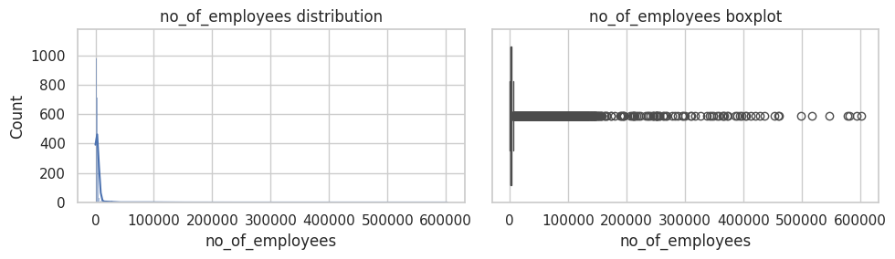

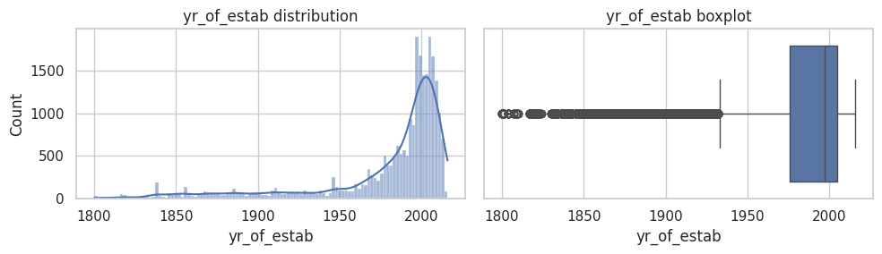

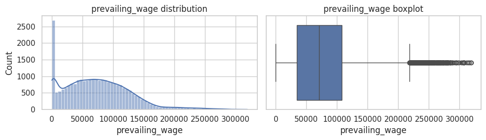

```python
# Numeric distributions + boxplots (for outliers)
num_cols = df.select_dtypes(include=np.number).columns.tolist()
for col in num_cols:
    fig, axes = plt.subplots(1, 2, figsize=(10,3))
    sns.histplot(df[col].dropna(), ax=axes[0], kde=True)
    axes[0].set_title(f"{col} distribution")
    sns.boxplot(x=df[col], ax=axes[1])
    axes[1].set_title(f"{col} boxplot")
    plt.tight_layout()
    plt.show()
```

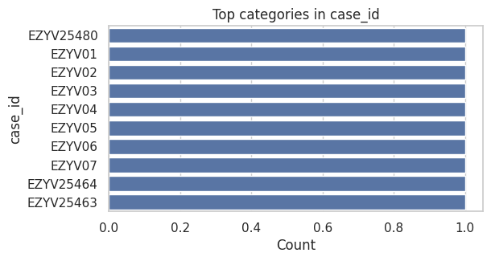

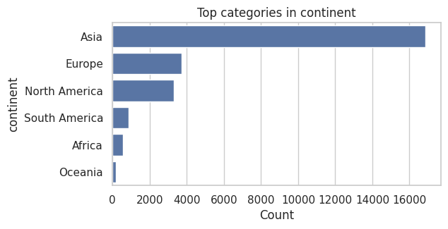

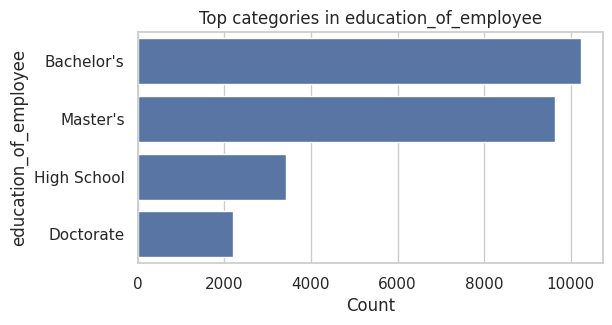

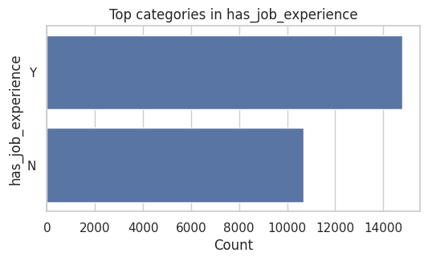

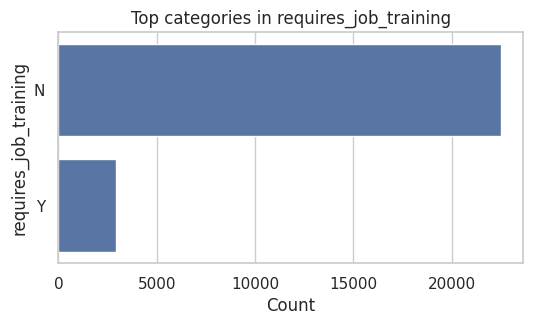

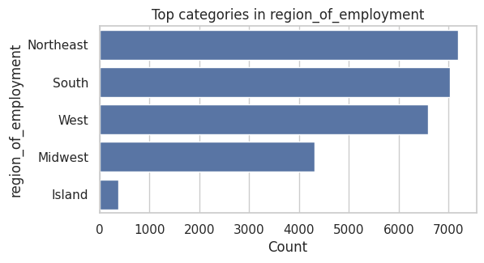

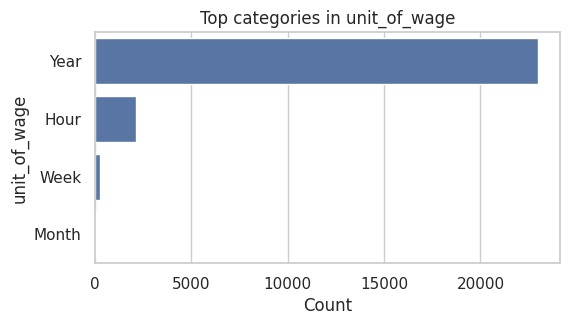

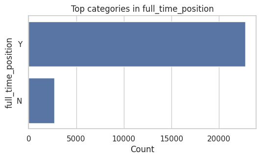

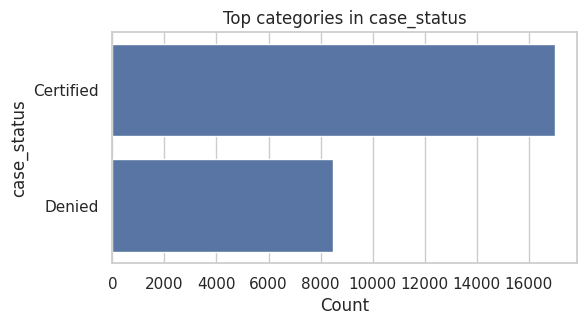

```python
# Categorical counts (limit to top 10 categories)
cat_cols = df.select_dtypes(include=['object','category']).columns.tolist()
for col in cat_cols:
    top = df[col].value_counts().nlargest(10)
    plt.figure(figsize=(6,3))
    sns.barplot(x=top.values, y=top.index)
    plt.title(f"Top categories in {col}")
    plt.xlabel("Count")
    plt.show()
```

### Conclusions

- Numeric features
  - no_of_employees
    - Median = 2,109 vs. Mean ≈ 5,667: strong right skew with a long tail (max ≈ 602K).
    - Negative values (min = –26) indicate data errors needing cleanup. Only 33 total records, so we can just impute the values.
    - ≈6% of records flagged as outliers by the IQR method (as noted earlier).
  - yr_of_estab
    - Distribution peaks in recent decades (1970–2016), but some very early values (min = 1800) need to be examined as placeholders or errors.
    - Median = 1997 vs. Mean ≈ 1979.
  - prevailing_wage
    - Right-skewed: median ≈ $70K vs. mean ≈ $74K, with values as low as $2 and as high as $319K, since some are hourly and some yearly.
    - The FAQs indicate that we don't need to standardize wages between hourly/yearly. After the analysis is done without treating the prevailing_wage column, one can find useful insights between the unit_of_wage and case_status columns.
    - Otherwise, tail behavior would suggest log transformation or capping before modeling.
- Categorical features
  - continent: Dominated by Asia (66%), then Europe (15%), North America (13%), others small.
  - education_of_employee: Four levels; Bachelor’s (40%), Master’s (38%), High School (13%), Doctorate (9%).
  - has_job_experience: 58% Y, 42% N.
  - requires_job_training: 88% N, 12% Y.
  - unit_of_wage: Mostly Year (90%), Hour (8.5%), Week/Month negligible.
  - full_time_position: 89% Y, 11% N.
  - case_status: 67% Certified, 33% Denied.
  - region_of_employment: Fairly even across Northeast (28%), South (27.5%), West (25.8%), Midwest (17%), but as expected, Island is much lower (1.5%).

Case Status by Unit of Wage

| Unit of Wage | Certified | Denied | Certification Rate |
| --- | --- | --- | --- |
| Hour | 747 | 1,410 | 34.63% |
| Month | 55 | 34 | 61.80% |
| Week | 169 | 103 | 62.13% |
| Year | 16,047 | 6,915 | 69.89% |

**Key Insights:**

- **Annual wages (“Year”)** have the highest approval rate at **≈70%**, indicating that positions paid on a yearly basis are far more likely to be certified.
- **Hourly wages (“Hour”)** show a notably low certification rate of only **≈35%**, suggesting hourly-paid roles face much tougher scrutiny.
- **Weekly (“Week”, 62%)** and **monthly (“Month”, 62%)** wage units fall in between, but still significantly below annual rates.
- The stark gap between “Year” vs “Hour” underscores that **billing the position on a yearly salary** may correlate strongly with approval success, perhaps reflecting more stable or higher-profile roles.

## Bivariate Analysis

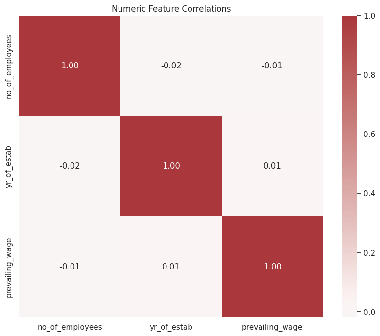

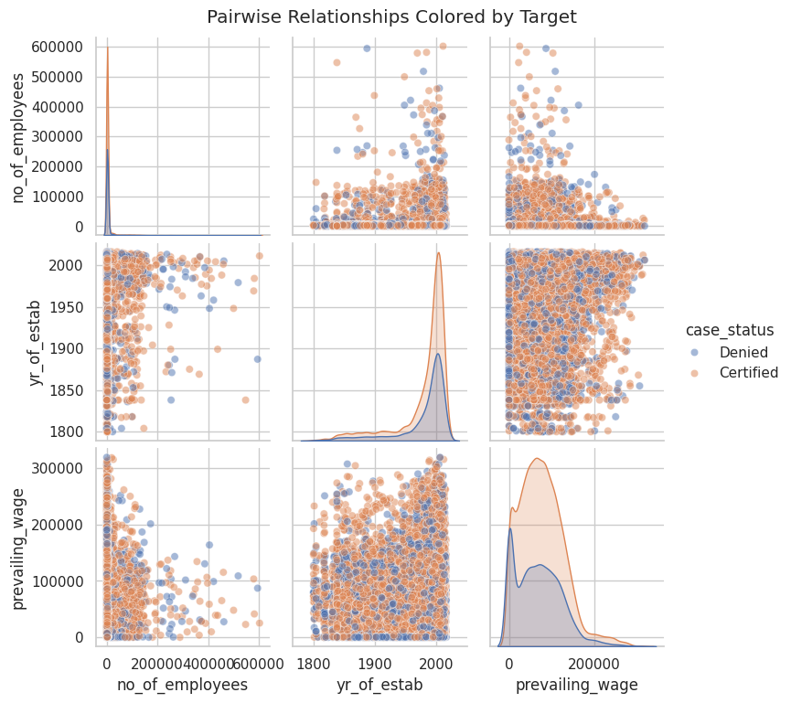

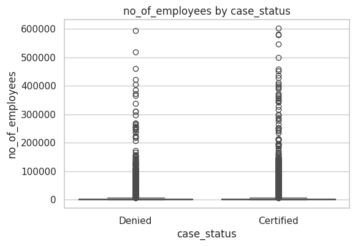

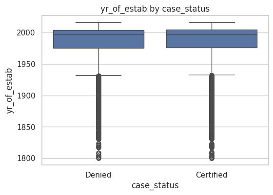

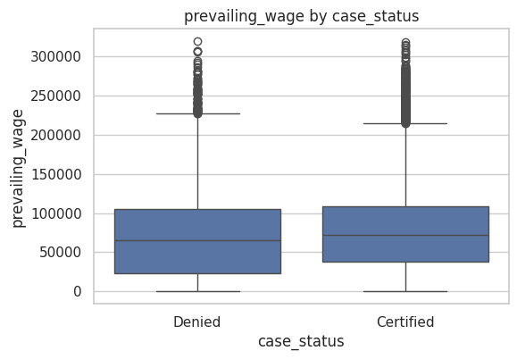

[figure not shown]

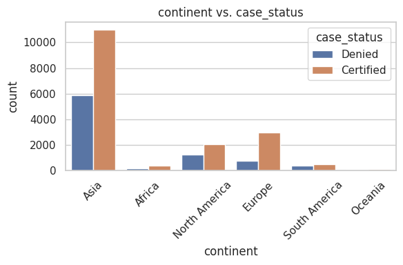

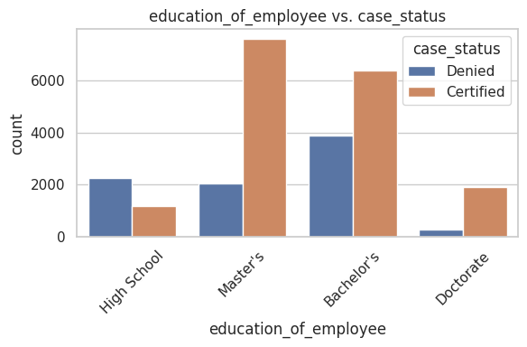

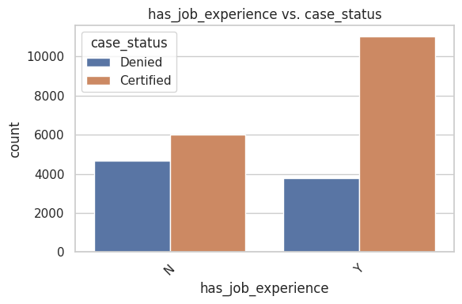

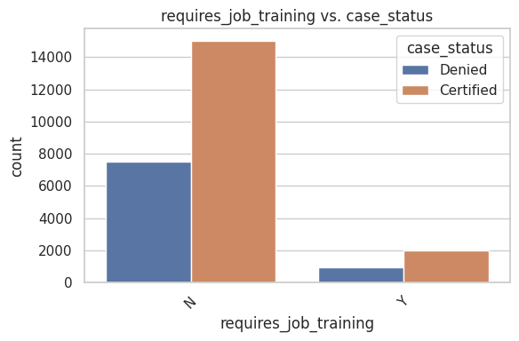

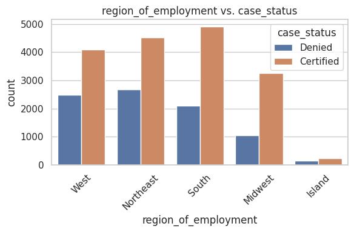

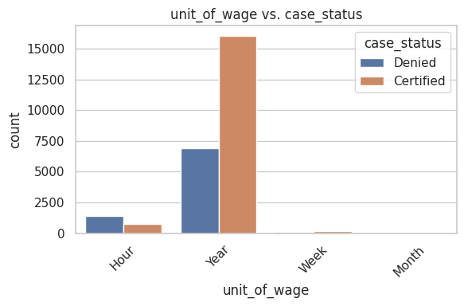

[2 more figures not shown]

```python
# Set up
sns.set(style="whitegrid")
target = 'case_status'  # replace with your actual target column

# Correlation heatmap for numeric–numeric
num_cols = df.select_dtypes(include=[np.number]).columns.tolist()
plt.figure(figsize=(10, 8))
corr = df[num_cols].corr()
sns.heatmap(corr, annot=True, fmt=".2f", cmap="vlag", center=0)
plt.title("Numeric Feature Correlations")
plt.show()

# Pairplot for a subset of key numerics
subset = ['no_of_employees', 'yr_of_estab', 'prevailing_wage']
sns.pairplot(df[subset + [target]], hue=target, plot_kws={'alpha':0.5})
plt.suptitle("Pairwise Relationships Colored by Target", y=1.02)
plt.show()

# Numeric vs. target: boxplots
for col in subset:
    plt.figure(figsize=(6, 4))
    sns.boxplot(x=target, y=col, data=df)
    plt.title(f"{col} by {target}")
    plt.show()

# Categorical vs. target: countplots
cat_cols = df.select_dtypes(include=['object','category']).columns.drop(target)
for col in cat_cols:
    plt.figure(figsize=(6, 4))
    sns.countplot(x=col, hue=target, data=df)
    plt.title(f"{col} vs. {target}")
    plt.xticks(rotation=45)
    plt.tight_layout()
    plt.show()

# Numeric–numeric scatter for two variables of interest
plt.figure(figsize=(6, 4))
sns.scatterplot(x='prevailing_wage', y='no_of_employees', hue=target, data=df, alpha=0.6)
plt.title("Employees vs. Wage, Colored by Target")
plt.show()
```

### Conclusions

Numeric–Target Correlations

Boxplots by Case Status

- Wages: Certified cases have a slightly higher median wage (~ $70 vs 65 K) and a tighter interquartile range, while Denied ones show both lower medians and slightly wider tails.
- Company Size: Certified employers have marginally higher median employee counts (around 2,200 vs 1,900).
- Establishment Year: Distributions look nearly identical, confirming age is not discriminatory between outcomes.

Categorical–Target Patterns

Wage vs Employees Scatter

- There’s a loose cluster of denials at both low‐wage/low‐size and very high‐wage/very large employers, but the bulk of approvals sits in the mid‐range (wages $40 – 120 K and employee counts under 10 K).

Key Takeaways

# **Data Pre-processing**

- Missing value treatment (if needed)
- Feature engineering (if needed)
- Outlier detection and treatment (if needed)
- Preparing data for modeling
- Any other preprocessing steps (if needed)

```python
# For testing purposes
df = df_copy.copy()

# Drop the case_id column in place:
if 'case_id' in df.columns:
    df.drop(columns=['case_id'], inplace=True)

# Check the df for any missing values
print(f"Missing values:\n{df.isnull().sum()}\n")

##################################################################

# Handle erroneous negative employee counts
# mark negative employee counts as missing
df['no_of_employees'] = df['no_of_employees'].mask(df['no_of_employees'] < 0, np.nan)

print(f"Number of employee counts fixed: {df['no_of_employees'].isnull().sum()}\n")

# compute the median of the valid values
median_employees = df['no_of_employees'].median()

# fill missing values with the median
df['no_of_employees'].fillna(median_employees, inplace=True)

# verify there are no negative values remaining
assert (df['no_of_employees'] >= 0).all()

##################################################################

# Define the mapping in increasing order of education level
education_mapping = {
    'High School': 1,
    "Bachelor's": 2,
    "Master's": 3,
    'Doctorate': 4
}

# Apply the mapping to create a new numeric column
df['education_level'] = df['education_of_employee'].map(education_mapping)
df[['education_of_employee', 'education_level']].drop_duplicates().sort_values('education_level')

# Check the result
print(df['education_level'].value_counts().sort_index(), "\n")

# Drop the old column
df.drop(columns=['education_of_employee'], inplace=True)

##################################################################

# binary-encodes y/n columns to reduce dummy variables
binary_cols = ['has_job_experience', 'requires_job_training', 'full_time_position']

# map 'Y' → 1, 'N' → 0
for col in binary_cols:
    df[col] = df[col].map({'Y': 1, 'N': 0})

# Verify the transformation
for col in binary_cols:
    print(f"Value counts for {col}:")
    print(df[col].value_counts(dropna=False))
    print()

# Ensure these columns are now type int
df[binary_cols] = df[binary_cols].astype(int)

# Map out case_status the same way
df['case_status'] = df['case_status'].map({'Certified':1, 'Denied':0}).astype(int)

# Calculate and print the percentage of Certified cases
print(f"Count of certified cases:\n{y.value_counts()}\n")
percent_certified = (y == 1).mean() * 100
print(f"Percentage of certified cases: {percent_certified:.2f}%\n")

##################################################################

# Feature engineering: compute company_age and drop yr_of_estab
if 'yr_of_estab' in df.columns:
  df['company_age'] = datetime.now().year - df['yr_of_estab']
  df.drop(columns=['yr_of_estab'], inplace=True)

# Display the type of each column
print(df.dtypes)
##################################################################

# Split the data

# split into train/val/test
X = df.drop(columns=['case_status'])
y = df['case_status']

# split off the test set (20% of the data)
X_temp, X_test_orig, y_temp, y_test = train_test_split(
    X, y, test_size=0.20, stratify=y, random_state=42
)

# split the remaining data into train and validation
X_train_orig, X_val_orig, y_train, y_val = train_test_split(
    X_temp, y_temp, test_size=0.25, stratify=y_temp, random_state=42
)

##################################################################

# Create a winsorization transformer
def winsorize_df(df_array):
    # df_array is a numpy array of shape (n_samples, n_features)
    # we'll compute 1st/99th percentiles column-wise on the training data
    global lower_bounds, upper_bounds
    return np.minimum(np.maximum(df_array, lower_bounds), upper_bounds)

# Precompute bounds on training data
numeric_cols = ['no_of_employees', 'company_age', 'prevailing_wage']
lower_bounds = X_train_orig[numeric_cols].quantile(0.01).values
upper_bounds = X_train_orig[numeric_cols].quantile(0.99).values

winsorizer = FunctionTransformer(winsorize_df)

##################################################################

# Build preprocessing pipelines
# define numeric vs. raw categorical features
numeric_features = [
    'no_of_employees',
    'company_age',
    'prevailing_wage',
    'education_level',
    'has_job_experience',
    'requires_job_training',
    'full_time_position'
]
categorical_features = X_train_orig.select_dtypes(include=['object']).columns.tolist()

# build transformers
numeric_transformer = Pipeline([
    ('imputer', SimpleImputer(strategy='median')),
    ('scaler',  RobustScaler())
])
categorical_transformer = Pipeline([
    ('imputer', SimpleImputer(strategy='most_frequent')),
    ('onehot',  OneHotEncoder(handle_unknown='ignore'))
])

preprocessor = ColumnTransformer(
    transformers=[
        ('num', numeric_transformer, numeric_features),
        ('cat', categorical_transformer, categorical_features)
    ],
    remainder='passthrough',            # keep all other columns
    verbose_feature_names_out=False
)

# Fit & transform train, val, and test sets
X_train = preprocessor.fit_transform(X_train_orig)
X_val   = preprocessor.transform(X_val_orig)
X_test  = preprocessor.transform(X_test_orig)

# Extract the transformed feature names
feature_names = preprocessor.get_feature_names_out()

print("Final feature count:", len(feature_names))

# extracts the indices from three datasets
# This is a common practice in machine learning pipelines to ensure proper dataset partitioning.
X_train_idx = X_train_orig.index.tolist()
X_val_idx = X_val_orig.index.tolist()
X_test_idx = X_test_orig.index.tolist()

##################################################################

# Verify the columns
print(f"Column list: {feature_names}\n")

# Verify shapes
print("Split Shapes:", X_train.shape, X_val.shape, X_test.shape)
```

```
Missing values:
continent                0
education_of_employee    0
has_job_experience       0
requires_job_training    0
no_of_employees          0
yr_of_estab              0
region_of_employment     0
prevailing_wage          0
unit_of_wage             0
full_time_position       0
case_status              0
dtype: int64

Number of employee counts fixed: 33

education_level
1     3420
2    10234
3     9634
4     2192
Name: count, dtype: int64

Value counts for has_job_experience:
has_job_experience
1    14802
0    10678
Name: count, dtype: int64

Value counts for requires_job_training:
requires_job_training
0    22525
1     2955
Name: count, dtype: int64

Value counts for full_time_position:
full_time_position
1    22773
0     2707
Name: count, dtype: int64
```

[output cut: 17 more lines]

```
case_status                int64
education_level            int64
company_age                int64
dtype: object
Final feature count: 22
Column list: ['no_of_employees' 'company_age' 'prevailing_wage' 'education_level'
 'has_job_experience' 'requires_job_training' 'full_time_position'
 'continent_Africa' 'continent_Asia' 'continent_Europe'
 'continent_North America' 'continent_Oceania' 'continent_South America'
 'region_of_employment_Island' 'region_of_employment_Midwest'
 'region_of_employment_Northeast' 'region_of_employment_South'
 'region_of_employment_West' 'unit_of_wage_Hour' 'unit_of_wage_Month'
 'unit_of_wage_Week' 'unit_of_wage_Year']

Split Shapes: (15288, 22) (5096, 22) (5096, 22)
```

## Metric Choice

- The single best metric here is the F₁ score on the “Certified” class—the harmonic mean of precision and recall for approvals.
- Precision alone risks missing too many true approvals (low recall) if we crank it up. I attempted this initially but was unhappy with the number of false negatives generated.
- Recall alone floods us with false positives (low precision).
- F₁ strikes a balance, ensuring we both catch genuine approvals and keep false‐positive “fast‐tracks” in check.
- Certified cases are imbalanced with 67% of cases being certified. We will want to handle that with over/under-sampling.

# Evaluation Functions

```python
def evaluate_model(model):
    """
    Evaluate a fitted classification model on pre-defined
    train/validation/test splits (X_train, y_train, X_val, y_val, X_test, y_test)
    and plot metrics, confusion matrices, and feature importances.
    """
    # 1) Metrics table
    splits = [
        ("Train", X_train, y_train),
        ("Validation", X_val, y_val),
        ("Test", X_test, y_test)
    ]
    records = []
    for name, Xd, yd in splits:
        preds = model.predict(Xd)
        records.append({
            "Dataset": name,
            "Accuracy": accuracy_score(yd, preds),
            "Recall": recall_score(yd, preds),
            "Precision": precision_score(yd, preds),
            "F1": f1_score(yd, preds)
        })
    df_metrics = pd.DataFrame(records).set_index("Dataset")
    print(df_metrics)

    # 2) Confusion matrices
    for name, Xd, yd in splits:
        cm = confusion_matrix(yd, model.predict(Xd))
        total = cm.sum()
        labels = np.array([f"{v}\n{v/total:.2%}" for v in cm.flatten()]).reshape(cm.shape)
        plt.figure(figsize=(5,4))
        sns.heatmap(cm, annot=labels, fmt="", cmap="Blues")
        plt.title(f"{name} Confusion Matrix")
        plt.ylabel("Actual")
        plt.xlabel("Predicted")
        plt.show()

    # 3) Feature importances (if available)
    if hasattr(model, "feature_importances_"):
        # retrieve feature names from fitted preprocessor
        feature_names = preprocessor.get_feature_names_out()
        importances = model.feature_importances_
        idx = np.argsort(importances)
        plt.figure(figsize=(8, max(4, len(feature_names)*0.3)))
        plt.barh([feature_names[i] for i in idx], importances[idx])
        plt.title("Feature Importances")
        plt.xlabel("Importance")
        plt.tight_layout()
        plt.show()
    else:
        print("Model has no feature_importances_ attribute.")
```

```python
def compare_multiple_models(models,
                            X_train=X_train, y_train=y_train,
                            X_val=X_val, y_val=y_val,
                            X_test=X_test, y_test=y_test):
    """
    Compare multiple classification models across train, validation, and test sets.

    Parameters:
    - models: dict mapping model names to fitted model objects
    - X_train, y_train: training data
    - X_val, y_val: validation data
    - X_test, y_test: test data

    Prints a table for each metric showing model performance side by side.
    """
    splits = {
        'Train': (X_train, y_train),
        'Validation': (X_val, y_val),
        'Test': (X_test, y_test)
    }
    metrics = {
        'Accuracy': accuracy_score,
        'Recall': recall_score,
        'Precision': precision_score,
        'F1': f1_score
    }

    # Initialize result DataFrames
    result_tables = {
        metric: pd.DataFrame(index=splits.keys(), columns=models.keys())
        for metric in metrics
    }

    # Compute metrics
    for model_name, model in models.items():
        for split_name, (X, y) in splits.items():
            y_pred = model.predict(X)
            for metric_name, metric_func in metrics.items():
                result_tables[metric_name].loc[split_name, model_name] = metric_func(y, y_pred)

    # Print tables
    for metric_name, table in result_tables.items():
        print(f"\n{metric_name} Comparison:")
        display(table)
```

# Base Model Building

## Gradient Boosting

```
            Accuracy    Recall  Precision        F1
Dataset
Train       0.759027  0.878660   0.785846  0.829665
Validation  0.747253  0.876873   0.774461  0.822492
Test        0.742936  0.873384   0.771807  0.819460
```

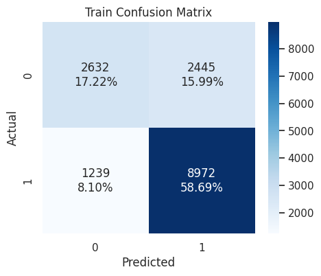

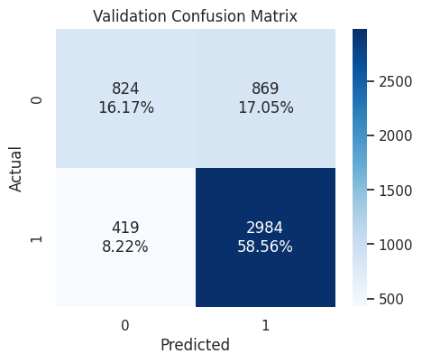

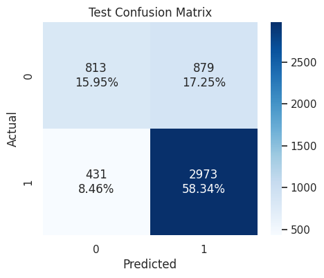

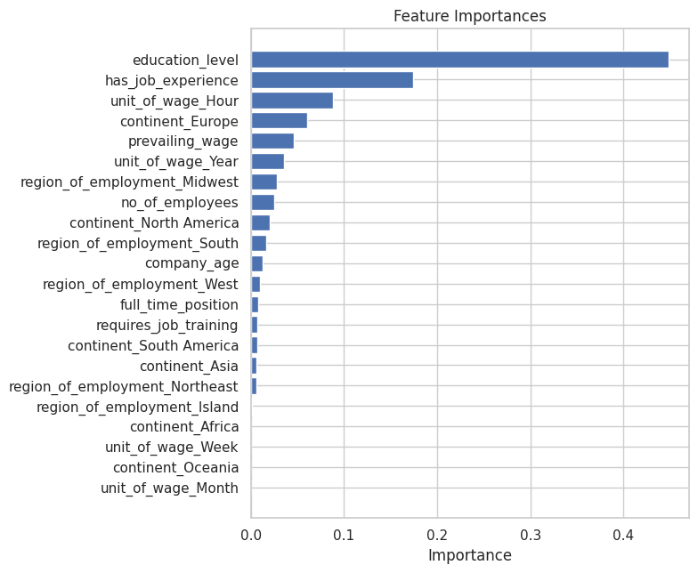

```python
# Gradient Boosting
gb_model = GradientBoostingClassifier(random_state=1)
gb_model.fit(X_train, y_train)

# Evaluate performance
evaluate_model(gb_model)
```